# Estimating and filtering out ambient mRNA for sc-/sn-RNA-Seq Analysis in 10X Genomics data

KIDS26 Team 15

**PI: Michael A. Dyer, PhD**  
**Project: sc-rna-seq-snap-sprocket-Victoria-Knockout-daedalus-v2**  
Task: Testing Cohort - stjude-biohackathon-KIDS26/KIDS26-Team15  
Project Lead(s): NA  
Department: Developmental Neurobiology

DNB Bioinformatics Core Analysis Team:

> **Lead Analyst(s): [REDACTED]**  
> Group Lead: [REDACTED]  
> **Contact E-mail:** [REDACTED]  
> **DNB Bioinformatics Core Pipeline:** Standard sc-/sn-RNA-Seq Analysis in 10X Genomics data

Date started: 09/16/2026  
Date completed: 09/18/2026  
Report generated: 01:16:57 UTC 09/18/2026

Reviewed by: _____________________ Date: ____________

# 1 Information about this notebook

[SoupX method](https://cran.r-project.org/web/packages/SoupX/vignettes/pbmcTutorial.html) profiles “the soup”, i.e., collection of cell-free mRNAs floating in the input solution. The soup looks different for each input solution and strongly resembles the expression pattern obtained by summing all the individual cells ([Young and Behjati, 2020](https://doi.org/10.1093/gigascience/giaa151)).

SoupX calculates `Cell-specific contamination fraction` (Estimate (or manually set) the contamination fraction, the fraction of UMIs originating from the background, in each cell) and infers a `corrected expression matrix` (Correct the expression of each cell using the ambient mRNA expression profile and estimated contamination).

The method to do this consists of three parts:

1. Calculate the profile of the soup.
2. Estimate the cell specific contamination fraction.
3. Infer a corrected expression matrix.

# 2 Set up

We will set up libraries necessary for this notebook.

```r
suppressPackageStartupMessages({
  library(future)
  library(knitr)
  library(SoupX)
  library(Seurat)
  library(stringr)
  library(tidyverse)
  library(tinytex)
  #library(SingleCellExperiment)
  library(Matrix)

  # Evaluate Seurat R expressions asynchronously when possible using future package
  source(normalizePath(file.path("..", "..", "scripts", "snap_parallel_plan.R"), winslash = "/"))
  snap_set_future_plan()})
```

```
## SNAP future plan: sequential; requested workers: 1; available cores: 8; selected workers: 1
```

# 3 Directories and paths to file Inputs/Outputs

We will set up directories and paths necessary for this notebook.

```r
attach(params)
```

```r
analysis_dir <- file.path(root_dir, "analyses", "upstream-analysis")
module_results_dir <- file.path(analysis_dir, paste0("results"))

# Input files
project_metadata_file <- file.path(metadata_dir, metadata_file) # metadata input file

# Create SoupX_results_dir
SoupX_results_dir <- file.path(module_results_dir, paste0("01_SoupX"))
if (!dir.exists(SoupX_results_dir)) {
  dir.create(SoupX_results_dir)}

# Create to plots directory
plots_dir <- file.path(analysis_dir, "plots")

# Create SoupX_plots_dir
SoupX_plots_dir <- file.path(plots_dir, paste0("01_SoupX"))
if (!dir.exists(SoupX_plots_dir)) {
  dir.create(SoupX_plots_dir)}

source(paste0(root_dir, "/figures/scripts/theme_plot.R"))
```

# 4 Read metadata file and define `sample_name`

```r
# Read metadata
project.metadata <- read.csv(project_metadata_file, sep = '\t', header = TRUE)
sample_name <- unique(as.character(project.metadata$ID))
sample_name <- sort(sample_name, decreasing = FALSE)
print(sample_name)
```

```
## [1] "DYE_2519" "DYE_2520" "DYE_2521" "DYE_2522"
```

# 5 Read in 10x data and run SoupX

We will estimate the contamination fraction `rho`. The posterior distribution is calculated using a Poisson likelihood with a gamma distribution prior, parametrised by its mean priorRho and standard deviation priorRhoStdDev. The dotted line in the above plot shows the prior distribution. The default parameters have been calibrated to be fairly non-specific with a slight preference towards values of rho in the 0% to 10% range which is most commonly seen for fresh (i.e. not nuclear) single cell experiments. The default values place only a very weak constraint, as can be seen by setting a uniform prior.

If contamination fraction estimate is > 20%, it is recommended to set `rho` manually. In this case, we will set 5% background to be removed by default.

```
## Beginning to process sample DYE_2519
## [1] "analyses/upstream-analysis/results/01_SoupX/DYE_2519"
## Reading in data
```

```
## 697 genes passed tf-idf cut-off and 218 soup quantile filter.  Taking the top 100.
```

```
## Using 550 independent estimates of rho.
```

```
## Estimated global rho of 0.02
```

```
## Channel with 33696 genes and 4865 cells
```

```
## Estimated soup fraction
##  is  0.024
```

```
## Expanding counts from 9 clusters to 4865 cells.
```

```
## Processing complete for sample DYE_2519
## Beginning to process sample DYE_2520
## [1] "analyses/upstream-analysis/results/01_SoupX/DYE_2520"
## Reading in data
```

```
## 2722 genes passed tf-idf cut-off and 728 soup quantile filter.  Taking the top 100.
```

```
## Using 307 independent estimates of rho.
```

```
## Estimated global rho of 0.04
```

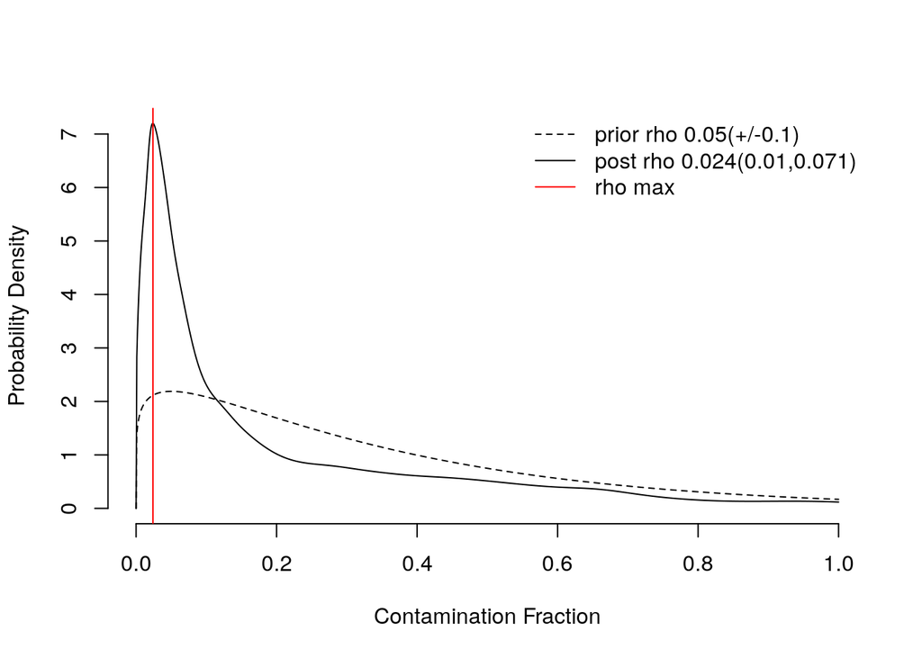

```
## Channel with 33696 genes and 7477 cells
```

```
## Estimated soup fraction
##  is  0.04
```

```
## Expanding counts from 9 clusters to 7477 cells.
```

```
## Processing complete for sample DYE_2520
## Beginning to process sample DYE_2521
## [1] "analyses/upstream-analysis/results/01_SoupX/DYE_2521"
## Reading in data
```

```
## 740 genes passed tf-idf cut-off and 91 soup quantile filter.  Taking the top 91.
```

```
## Using 655 independent estimates of rho.
```

```
## Estimated global rho of 0.04
```

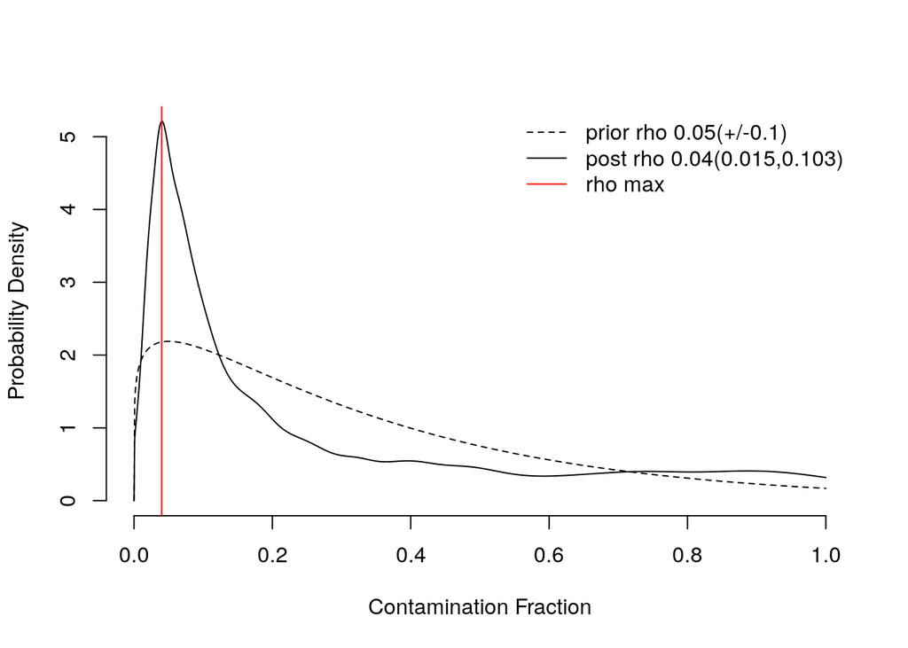

```
## Channel with 33696 genes and 6351 cells
```

```
## Estimated soup fraction
##  is  0.037
```

```
## Expanding counts from 11 clusters to 6351 cells.
```

```
## Processing complete for sample DYE_2521
## Beginning to process sample DYE_2522
## [1] "analyses/upstream-analysis/results/01_SoupX/DYE_2522"
## Reading in data
```

```
## 1871 genes passed tf-idf cut-off and 277 soup quantile filter.  Taking the top 100.
```

```
## Using 474 independent estimates of rho.
```

```
## Estimated global rho of 0.02
```

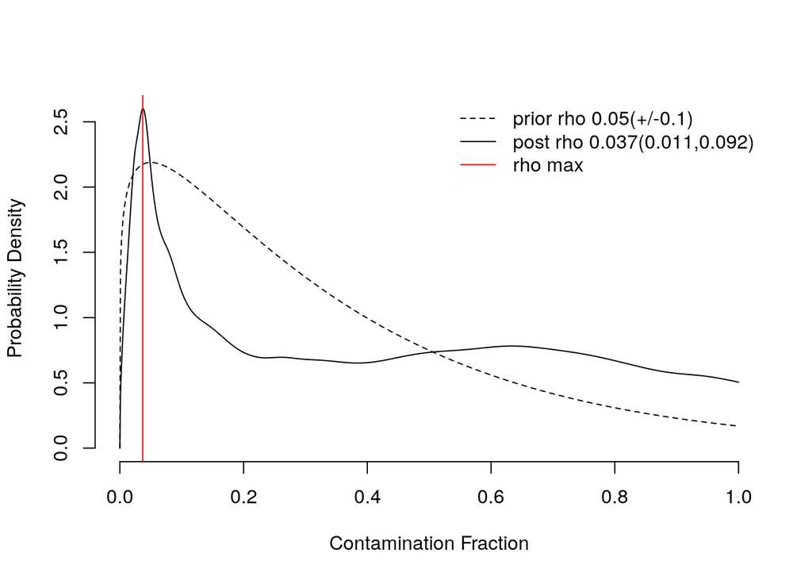

```
## Channel with 33696 genes and 8208 cells
```

```
## Estimated soup fraction
##  is  0.024
```

```
## Expanding counts from 10 clusters to 8208 cells.
```

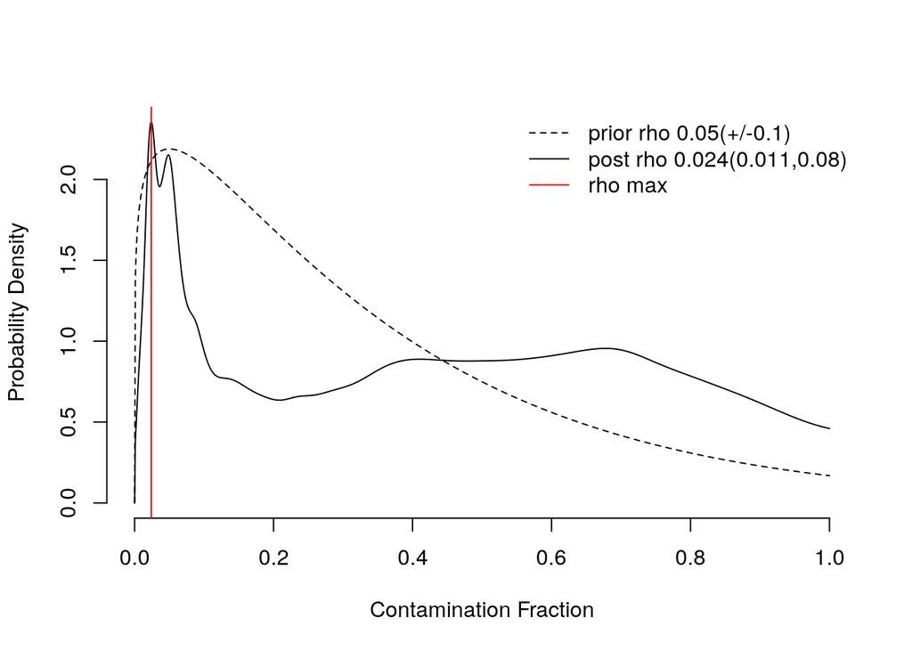

```
## Processing complete for sample DYE_2522
```

```r
# Create contamination summary table
contamination_summary <- matrix(ncol = 4, nrow = 1) %>% as.data.frame()
colnames(contamination_summary) <- c("sample_name", "rho_estimated_by_SoupX", "rho_adjusted", "rho_removed")

for (i in seq_along(sample_name)) {

  cat("Beginning to process sample", sample_name[i], "\n")

  # Create directory
  samples_SoupX_results_dir <- file.path(SoupX_results_dir, sample_name[i])
  if (!dir.exists(samples_SoupX_results_dir)) {
    dir.create(samples_SoupX_results_dir)}
  print(samples_SoupX_results_dir)

  #strainedCounts_SoupX_results_dir <- file.path(samples_SoupX_results_dir, "strainedCounts")
  #if (!dir.exists(strainedCounts_SoupX_results_dir)) {
  #  dir.create(strainedCounts_SoupX_results_dir)}
  # print(strainedCounts_SoupX_results_dir)

  cat("Reading in data\n")

  filtered_matrix_file <- file.path(data_dir, sample_name[i], "outs", "filtered_feature_bc_matrix.h5")
  raw_matrix_file <- file.path(data_dir, sample_name[i], "outs", "raw_feature_bc_matrix.h5")
  clusters_file <- file.path(data_dir, sample_name[i], "outs", "analysis", "clustering", "gene_expression_graphclust", "clusters.csv")

  # Read data
  filtered_matrix <- Seurat::Read10X_h5(filtered_matrix_file, use.names = TRUE)
  raw_matrix <- Seurat::Read10X_h5(raw_matrix_file, use.names = TRUE)
  clusters <- read.csv(clusters_file)

  # Save plot
  #pdf(file = paste0(SoupX_plots_dir, "/", sample_name[i], "_SoupX_contamination_fraction_plot.pdf", sep = ""))

  # Create df
  mDat <- data.frame(clusters=clusters$Cluster, row.names=clusters$Barcode)

  # Make a “SoupChannel”, the object needed to run SoupX
  sc_raw <- SoupChannel(raw_matrix, filtered_matrix, mDat)

  # Estimate contamination fraction rho
  sc <- autoEstCont(sc_raw, forceAccept = TRUE)
  print(sc)
  soup_fraction_value <- sc$fit$rhoEst

  # To not remove more than 20% background
  if (soup_fraction_value > 0.2) {
    print(soup_fraction_value)
    cat("Estimated soup fraction >20%, set to 5% by default.\n")
    sc = setContaminationFraction(sc_raw, soup_fraction_value_default)
    contamination_summary[i,] <- c(sample_name[i], soup_fraction_value, "yes", soup_fraction_value_default)
    print(sc)
    } else {
      cat("Estimated soup fraction\n is ", `soup_fraction_value`, "\n")
      contamination_summary[i,] <- c(sample_name[i], soup_fraction_value, "no", soup_fraction_value)}

  # Correcting expression profile and clean data
  # This will contain a corrected matrix to be used in place of the original table of counts in downstream analyses.
  out <- adjustCounts(sc, roundToInt = TRUE) # roundToInt option to make sure we output integer matrix
  colnames(out) <- paste0(sample_name[i], ":", colnames(out))
  colnames(out) = gsub('-1$','', colnames(out)) # remove -1

  #DropletUtils:::write10xCounts(paste(SoupX_results_dir, "./strainedCounts", sep = ""), out_merge, overwrite = TRUE) #library(DropletUtils)
  #write10xCounts(path = file.path(SoupX_results_dir, sample_name[i], "strainedCounts"), x = out) #library(SingleCellExperiment)
  #Write10X(out_merge, path = file.path(SoupX_results_dir, "strainedCounts")) #library(Seurat)

  #writeMM(out, file = file.path(strainedCounts_SoupX_results_dir, "matrix.mtx"))

  # Write barcodes (column names of the count matrix)
  #write.table(colnames(out), file = file.path(strainedCounts_SoupX_results_dir, "barcodes.tsv"),
  #          quote = FALSE, row.names = FALSE, col.names = FALSE)

  # Write features (row names of the count matrix)
  #write.table(rownames(out), file = file.path(strainedCounts_SoupX_results_dir, "features.tsv"),
  #          quote = FALSE, row.names = FALSE, col.names = FALSE)

  saveRDS(out, file.path(samples_SoupX_results_dir, "mtx_corrected_SoupX.rds")) # Save combined matrices

  cat("Processing complete for sample", sample_name[i], "\n")

  # Let's combine corrected matrices from all samples
  # We will use this file in later stage of the `upstream-analysis` module
  #  if(i==1) {
  #    out_merge <- out
  #    } else {
  #      out_merge <- cbind(out_merge, out) }
  #dev.off()
}
```

# 6 Contamination fraction `rho` per sample

We will summarize the estimated and removed background due to contamination per sample.

Summary of contamination fraction per sample

| sample_name | rho_estimated_by_SoupX | rho_adjusted | rho_removed |
| --- | --- | --- | --- |
| DYE_2519 | 0.024 | no | 0.024 |
| DYE_2520 | 0.04 | no | 0.04 |
| DYE_2521 | 0.037 | no | 0.037 |
| DYE_2522 | 0.024 | no | 0.024 |

# 7 Save output files

```r
#saveRDS(out_merge, file.path(SoupX_results_dir, "SoupX_corrected_mtx_merged.rds")) # Save combined matrices

contamination_summary %>%
  write_tsv(file.path(SoupX_results_dir,"SoupX_contamination_summary.tsv")) # Save `contamination_summary`
```